# House Saleprice Prediction project

Yuan Gao

8/3/2020

**Title** Regression Model for House Prices Prediction

## Introduction

**Dataset Descripton**

The datasets are house prices dataset from Kaggle, including a training dataset (house_trn.csv) and a test dataset (house_tst.csv). The training dataset has 81 columns and 1460 records and the test dataset has 80 columns and 1459 records.

We pick this dataset because it provides many features potentially related to house price, which is good for us to explore and find a good model.

MSZoning: Identifies the general zoning classification of the sale.

```
   A    Agriculture
   C    Commercial
   FV   Floating Village Residential
   I    Industrial
   RH   Residential High Density
   RL   Residential Low Density
   RP   Residential Low Density Park
   RM   Residential Medium Density
```

LotFrontage: Linear feet of street connected to property

LotArea: Lot size in square feet

Neighborhood: Physical locations within Ames city limits

```
   Blmngtn  Bloomington Heights
   Blueste  Bluestem
   BrDale   Briardale
   BrkSide  Brookside
   ClearCr  Clear Creek
   CollgCr  College Creek
   Crawfor  Crawford
   Edwards  Edwards
   Gilbert  Gilbert
   IDOTRR   Iowa DOT and Rail Road
   MeadowV  Meadow Village
   Mitchel  Mitchell
   Names    North Ames
   NoRidge  Northridge
   NPkVill  Northpark Villa
   NridgHt  Northridge Heights
   NWAmes   Northwest Ames
   OldTown  Old Town
   SWISU    South & West of Iowa State University
   Sawyer   Sawyer
   SawyerW  Sawyer West
   Somerst  Somerset
   StoneBr  Stone Brook
   Timber   Timberland
   Veenker  Veenker
```

BldgType: Type of dwelling

```
   1Fam Single-family Detached
   2FmCon   Two-family Conversion; originally built as one-family dwelling
   Duplx    Duplex
   TwnhsE   Townhouse End Unit
   TwnhsI   Townhouse Inside Unit
```

HouseStyle: Style of dwelling

```
   1Story   One story
   1.5Fin   One and one-half story: 2nd level finished
   1.5Unf   One and one-half story: 2nd level unfinished
   2Story   Two story
   2.5Fin   Two and one-half story: 2nd level finished
   2.5Unf   Two and one-half story: 2nd level unfinished
   SFoyer   Split Foyer
   SLvl Split Level
```

OverallCond: Rates the overall condition of the house

```
   10   Very Excellent
   9    Excellent
   8    Very Good
   7    Good
   6    Above Average
   5    Average
   4    Below Average
   3    Fair
   2    Poor
   1    Very Poor
```

SaleCondition: Condition of sale

```
   Normal   Normal Sale
   Abnorml  Abnormal Sale -  trade, foreclosure, short sale
   AdjLand  Adjoining Land Purchase
   Alloca   Allocation - two linked properties with separate deeds, typically condo with a garage unit
   Family   Sale between family members
   Partial  Home was not completed when last assessed (associated with New Homes)
```

**Reason and Goal**

- Reason

House price is important for almost everyone who ever consider buying a house or building a house.

House price prediction is important for people who want to buy a house for residence purpose or for investment purpose. It gives them an idea of the price when negoiating with the house seller. For example, they get a predicted price based on the LotArea, LotShape, Neighborhood and other factors. If there is a discrepency between this predicted price and listing price, they maybe able to negotiate better based on the prediction information.

Knowing what could infludence house price also give house builder an idea of where or what kind of house they should make or what feature they should add to the house to max their profit.

- Goal

We would like to use the multiple regression model created based on this dataset to predict house price for houses in Ames City.

## Methods

### Data Preprocessing

- Import and clean data.
- Transform certain data to factor type,so to be used as dummy variables.

```r
# Preprocessing: Import and clean data
library(readr)
data=read.csv('house_trn.csv')
data=data[c('MSZoning','LotFrontage','LotArea','Neighborhood','BldgType','HouseStyle','OverallCond','SaleCondition','SalePrice')]
data=na.omit(data)
data$MSZoning=as.factor(data$MSZoning)
data$Neighborhood=as.factor(data$Neighborhood)
data$BldgType=as.factor(data$BldgType)
data$HouseStyle=as.factor(data$HouseStyle)
data$OverallCond=as.factor(data$OverallCond)
data$SaleCondition=as.factor(data$SaleCondition)

# Split data dataset into training data and test data
smp_size <- floor(0.75 * nrow(data))
## set the seed to make your partition reproducible
set.seed(123)
train_ind <- sample(seq_len(nrow(data)), size = smp_size)
train = data[train_ind, ]
test=data[-train_ind, ]
```

### Plot of Response(SalePrice) against each factors

Visualize the relationships to see if there is discernable linear relationship.

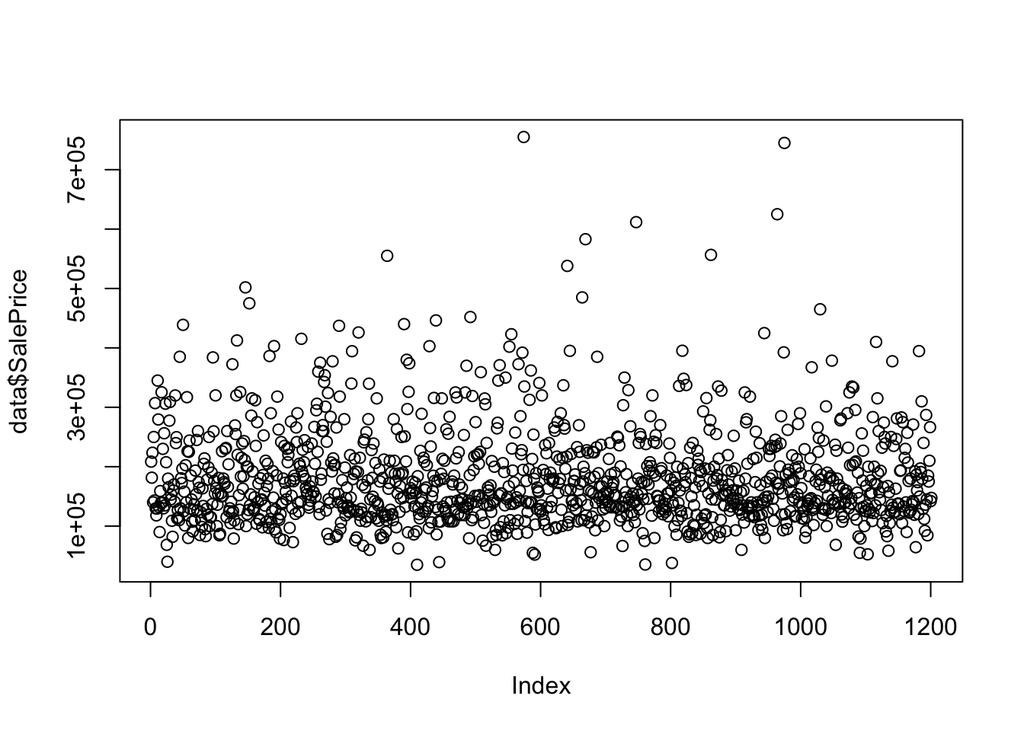

```r
#pairs(train)
# Plot SalePrice
plot(data$SalePrice,type="p")
```

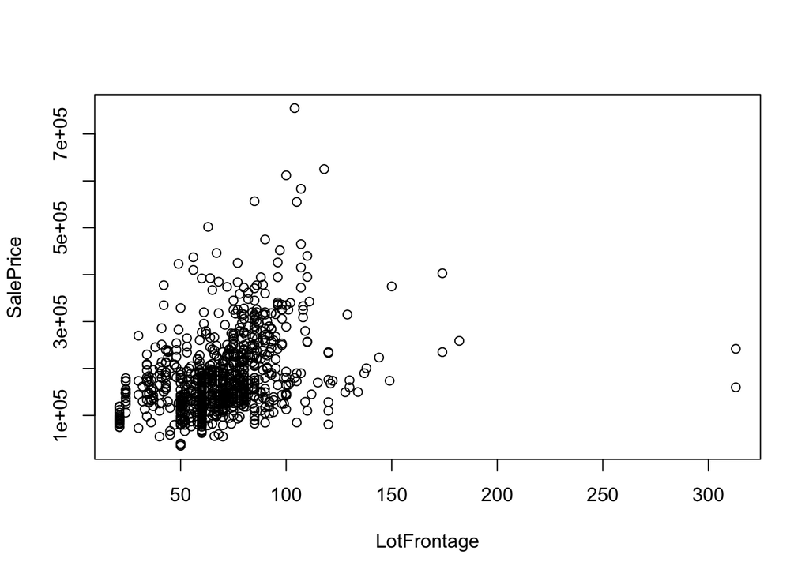

```r
# Plot SalePrice against other features
plot(SalePrice~LotFrontage, data=train)
```

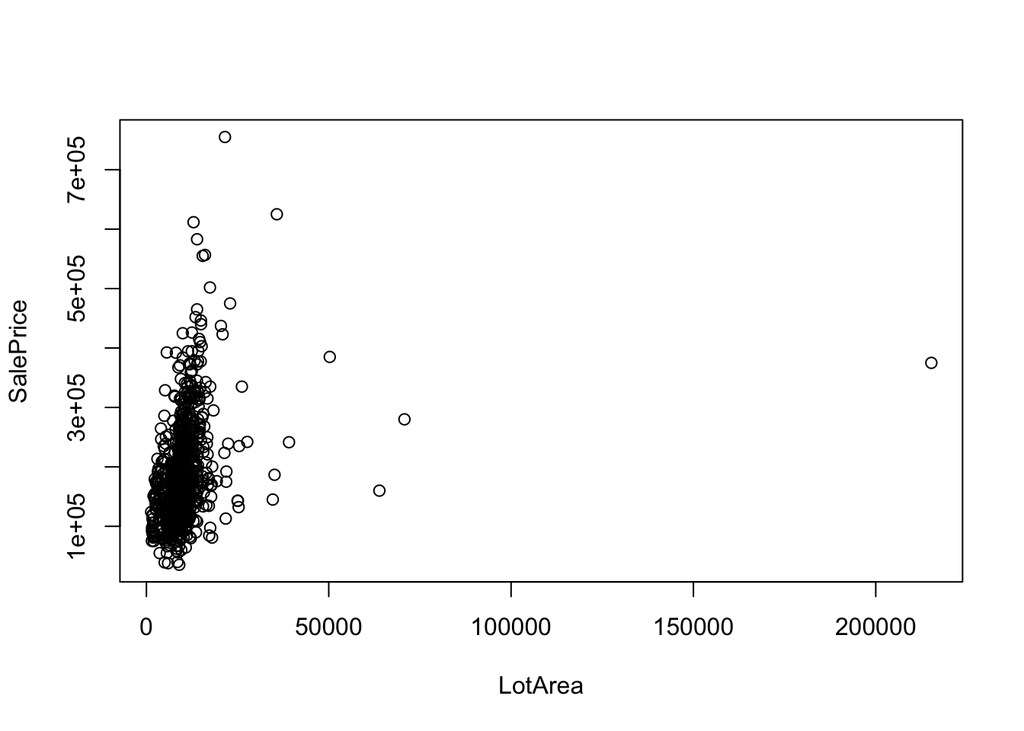

```r
plot(SalePrice~LotArea, data=train)
```

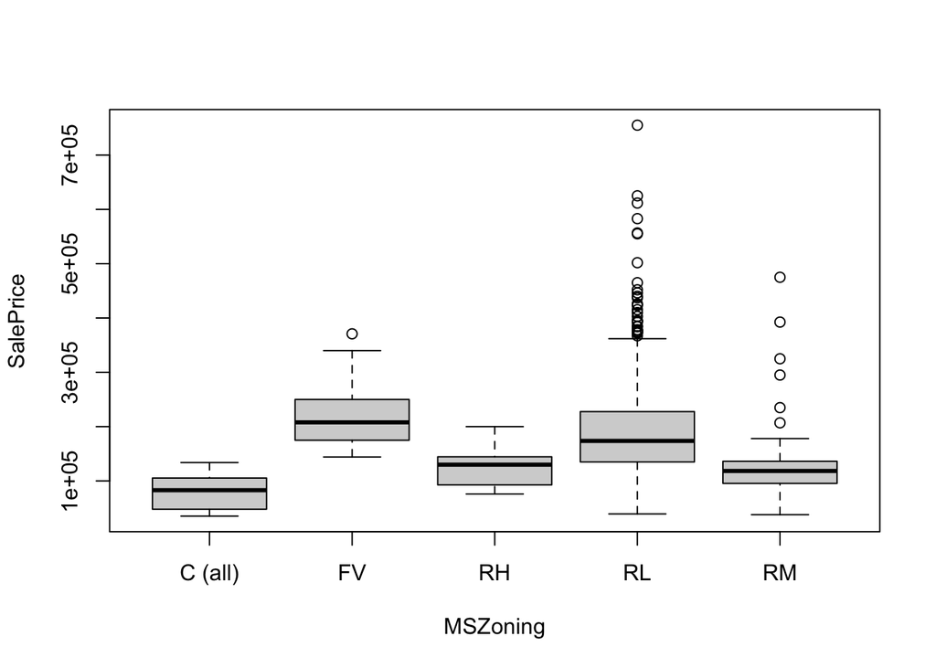

```r
plot(SalePrice~MSZoning,data=train)
```

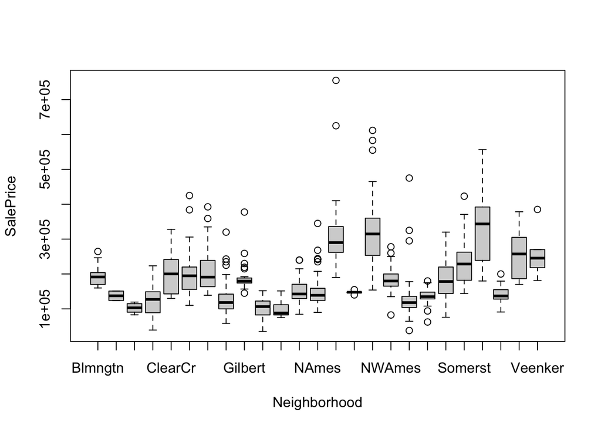

```r
plot(SalePrice~Neighborhood,data=train)
```

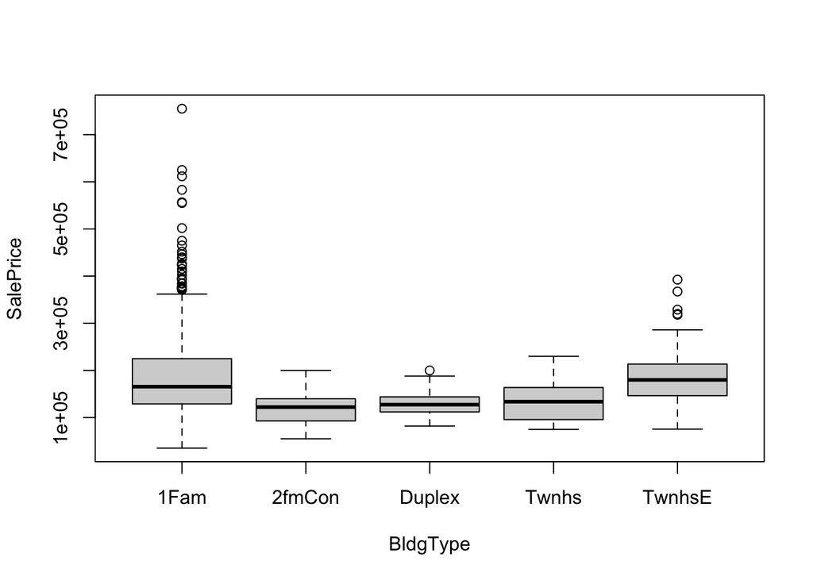

```r
plot(SalePrice~BldgType,data=train)
```

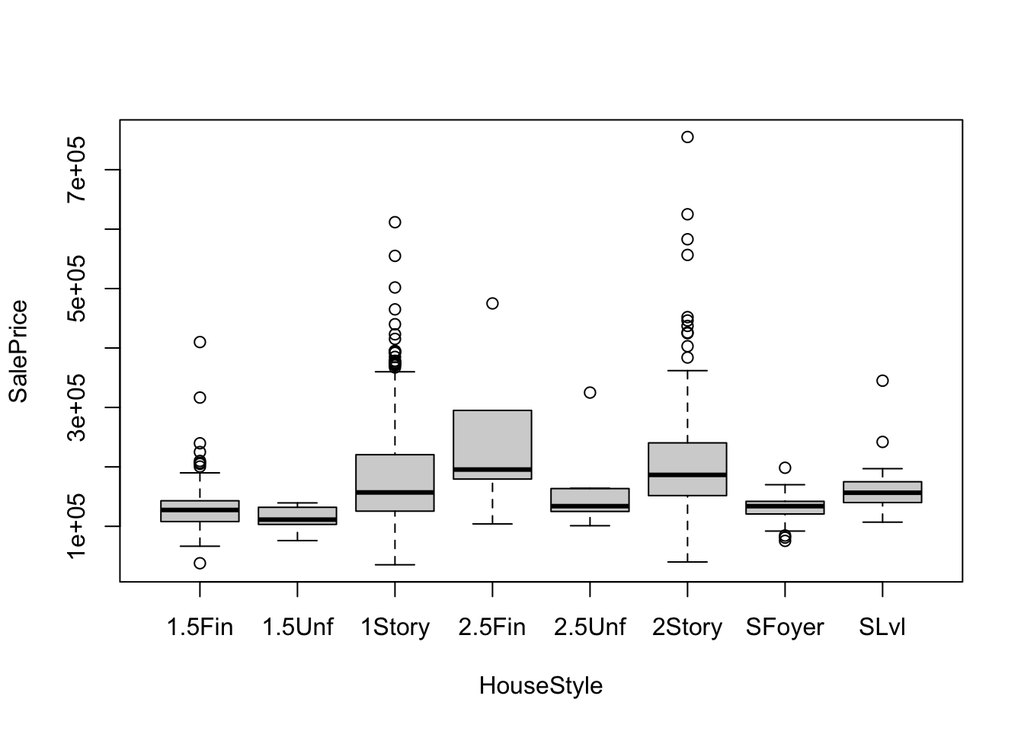

```r
plot(SalePrice~HouseStyle,data=train)
```

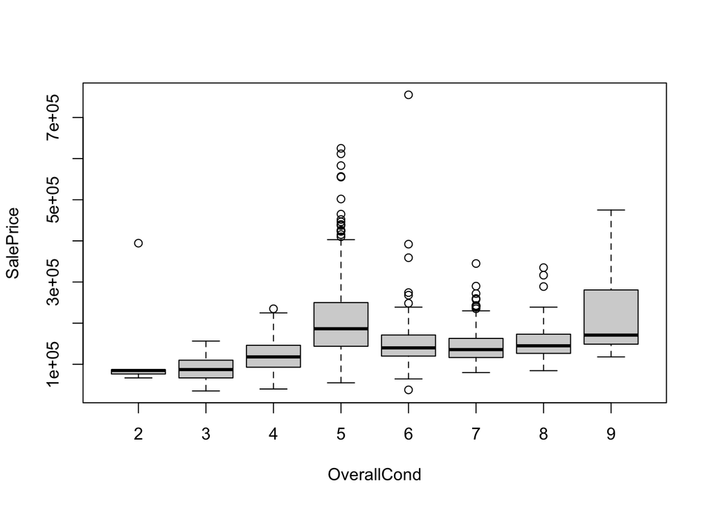

```r
plot(SalePrice~OverallCond,data=train)
```

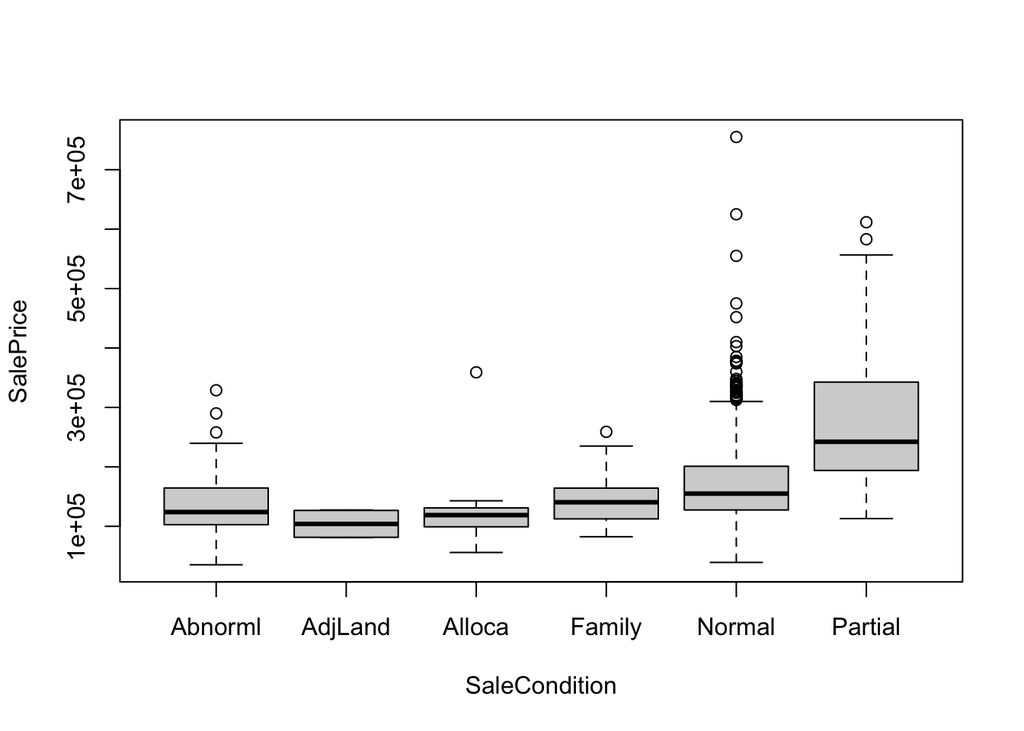

```r
plot(SalePrice~SaleCondition,data=train)
```

```r
outlier1=train[which.max(train$LotArea),]
outlier2=train[which.max(train$LotFrontage),]
a=which.max(train$LotArea)
b=which.max(train$LotFrontage)
outliers=c(a,b)
```

- By observing the graph, we would see that there could be a linear relationship between SalePrice and LotFrontage, SalsPrice and LotArea and there are also outliers and influential points, which we may consider removing later.

### Model Selection

#### Additive Model

We would like to find the best additive model possible for prediciting house SalePrice based on our dataset. The steps we take are as following:

- Start with Oringinal additive model with all factors
- check collinearity, compare the model with high GVIF removed and original additive model Comparing adjusted r squared, removing highest GVIF won’t improve adjusted r squared,choose the original additive model
- Use backward BIC to choose a model, compare this model to the original additive model Performing anova test, choose the orginal additive model
- Check normality and equal variance assumptions on the model we picked after the previous steps. Performind bptest and shapiro test, failed both perform visualization of qqplot and resdiual plot, in order to understand the distribution better and have an idea of what transformation to conduct later.
- Calculate adjusted R squared, to evluate it how good the model fit the training data
- Calculate RMSE and r squared on test dataset, to evaluate how good the data generalize to test data

```r
# Find the best additive model

## Additive Model, use all factors as predictor
library(car)
library(lmtest)
########## MODEL 1 ##################
model_add=lm(SalePrice~. ,data=train)
summary(model_add)
```

```
##
## Call:
## lm(formula = SalePrice ~ ., data = train)
##
## Residuals:
##     Min      1Q  Median      3Q     Max
## -185475  -24666   -4409   16035  411849
##
## Coefficients:
##                        Estimate Std. Error t value Pr(>|t|)
## (Intercept)           1.428e+05  3.714e+04   3.846 0.000129 ***
## MSZoningFV           -3.093e+03  2.639e+04  -0.117 0.906714
## MSZoningRH            2.382e+02  2.738e+04   0.009 0.993060
## MSZoningRL            1.851e+04  2.237e+04   0.828 0.408170
## MSZoningRM            2.739e+04  2.067e+04   1.325 0.185511
## LotFrontage           4.209e+02  9.243e+01   4.554 6.03e-06 ***
## LotArea               1.240e+00  2.270e-01   5.461 6.21e-08 ***
## NeighborhoodBlueste  -4.662e+04  4.023e+04  -1.159 0.246799
## NeighborhoodBrDale   -6.954e+04  2.496e+04  -2.786 0.005450 **
## NeighborhoodBrkSide  -1.001e+05  2.013e+04  -4.972 8.02e-07 ***
## NeighborhoodClearCr  -4.892e+04  2.342e+04  -2.089 0.037010 *
## NeighborhoodCollgCr  -3.759e+04  1.725e+04  -2.180 0.029564 *
## NeighborhoodCrawfor  -2.893e+04  1.945e+04  -1.488 0.137215
## NeighborhoodEdwards  -9.493e+04  1.780e+04  -5.333 1.24e-07 ***
## NeighborhoodGilbert  -6.093e+04  1.854e+04  -3.287 0.001056 **
## NeighborhoodIDOTRR   -1.209e+05  2.310e+04  -5.235 2.08e-07 ***
## NeighborhoodMeadowV  -7.505e+04  2.447e+04  -3.067 0.002229 **
## NeighborhoodMitchel  -7.546e+04  1.950e+04  -3.869 0.000118 ***
## NeighborhoodNAmes    -8.205e+04  1.726e+04  -4.752 2.36e-06 ***
## NeighborhoodNoRidge   7.137e+04  1.959e+04   3.644 0.000285 ***
## NeighborhoodNPkVill  -2.628e+04  2.618e+04  -1.004 0.315755
## NeighborhoodNridgHt   7.486e+04  1.684e+04   4.445 9.97e-06 ***
## NeighborhoodNWAmes   -5.138e+04  1.900e+04  -2.704 0.006988 **
## NeighborhoodOldTown  -1.119e+05  2.035e+04  -5.496 5.15e-08 ***
## NeighborhoodSawyer   -9.133e+04  1.867e+04  -4.892 1.20e-06 ***
## NeighborhoodSawyerW  -4.076e+04  1.825e+04  -2.234 0.025770 *
## NeighborhoodSomerst   1.341e+04  2.005e+04   0.669 0.503959
## NeighborhoodStoneBr   1.056e+05  2.012e+04   5.247 1.95e-07 ***
## NeighborhoodSWISU    -9.088e+04  2.114e+04  -4.298 1.92e-05 ***
## NeighborhoodTimber   -2.397e+03  1.929e+04  -0.124 0.901168
```

[output cut: 15 more lines]

```
## OverallCond6          1.853e+04  2.344e+04   0.790 0.429570
## OverallCond7          2.066e+04  2.345e+04   0.881 0.378705
## OverallCond8          2.305e+04  2.426e+04   0.950 0.342312
## OverallCond9          7.173e+04  2.763e+04   2.596 0.009595 **
## SaleConditionAdjLand  4.646e+03  2.692e+04   0.173 0.863019
## SaleConditionAlloca   6.405e+03  2.108e+04   0.304 0.761353
## SaleConditionFamily   8.383e+03  1.425e+04   0.588 0.556546
## SaleConditionNormal   1.251e+04  6.570e+03   1.905 0.057174 .
## SaleConditionPartial  3.903e+04  8.997e+03   4.338 1.61e-05 ***
## ---
## Signif. codes:  0 '***' 0.001 '**' 0.01 '*' 0.05 '.' 0.1 ' ' 1
##
## Residual standard error: 49820 on 846 degrees of freedom
## Multiple R-squared:  0.6669, Adjusted R-squared:  0.646
## F-statistic: 31.96 on 53 and 846 DF,  p-value: < 2.2e-16
```

**Check Collinearity**

```r
car::vif(model_add)
```

```
##                     GVIF Df GVIF^(1/(2*Df))
## MSZoning       21.296952  4        1.465682
## LotFrontage     1.843614  1        1.357797
## LotArea         1.363338  1        1.167621
## Neighborhood  266.410285 24        1.123395
## BldgType        5.305683  4        1.231949
## HouseStyle      3.115738  7        1.084562
## OverallCond     2.969938  7        1.080856
## SaleCondition   2.137477  5        1.078922
```

```r
# Remove Neighbor with highest GVIF
model_add_nN=lm(SalePrice~.-Neighborhood ,data=train)
add_R_nN=summary(model_add_nN)$adj.r.squared
# Compare adjusted R squared between two models
add_R=summary(model_add)$adj.r.squared
ifelse(add_R_nN>add_R,'REMOVE HIGH GVIF','NOT REMOVE HIGH GIVF')
```

```
## [1] "NOT REMOVE HIGH GIVF"
```

**Model Selection**

```r
## Use backward BIC to select predictors,small pvalue, reject null, keep original additive model
model_add_bic=step(model_add,k=log(nrow(train)),trace=0)
add_R_bic=summary(model_add_bic)$adj.r.squared
# Anova test: Compare additive model with all factors and the one chosen by backward BIC, turns out Orignial one is better than the one chosen by backward BIC
ifelse(add_R_bic>add_R,'BIC GOOD','ORIGINAL GOOD')
```

```
## [1] "ORIGINAL GOOD"
```

```r
anova(model_add_bic,model_add)
```

```
## Analysis of Variance Table
##
## Model 1: SalePrice ~ LotFrontage + LotArea + Neighborhood
## Model 2: SalePrice ~ MSZoning + LotFrontage + LotArea + Neighborhood +
##     BldgType + HouseStyle + OverallCond + SaleCondition
##   Res.Df        RSS Df  Sum of Sq      F    Pr(>F)
## 1    873 2.4222e+12
## 2    846 2.1001e+12 27 3.2204e+11 4.8047 4.079e-14 ***
## ---
## Signif. codes:  0 '***' 0.001 '**' 0.01 '*' 0.05 '.' 0.1 ' ' 1
```

**Assumption tests: Normality & Equal Variance**

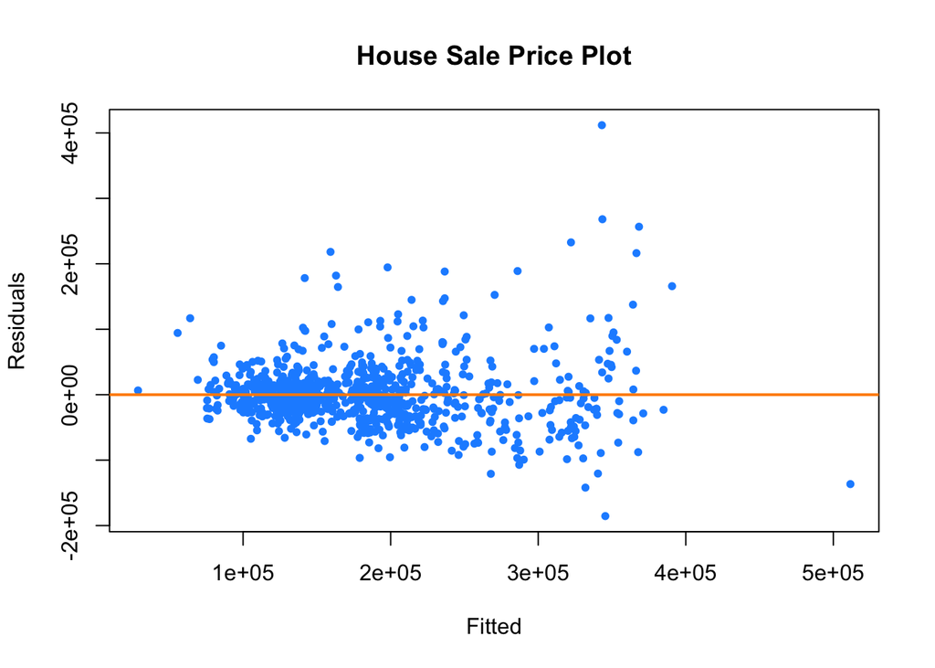

```r
# Check equal variance by residual plot
plot(fitted(model_add),resid(model_add),col='dodgerblue',pch=20,xlab='Fitted',ylab='Residuals',main='House Sale Price Plot')
abline(h=0,col='darkorange',lwd=2)
```

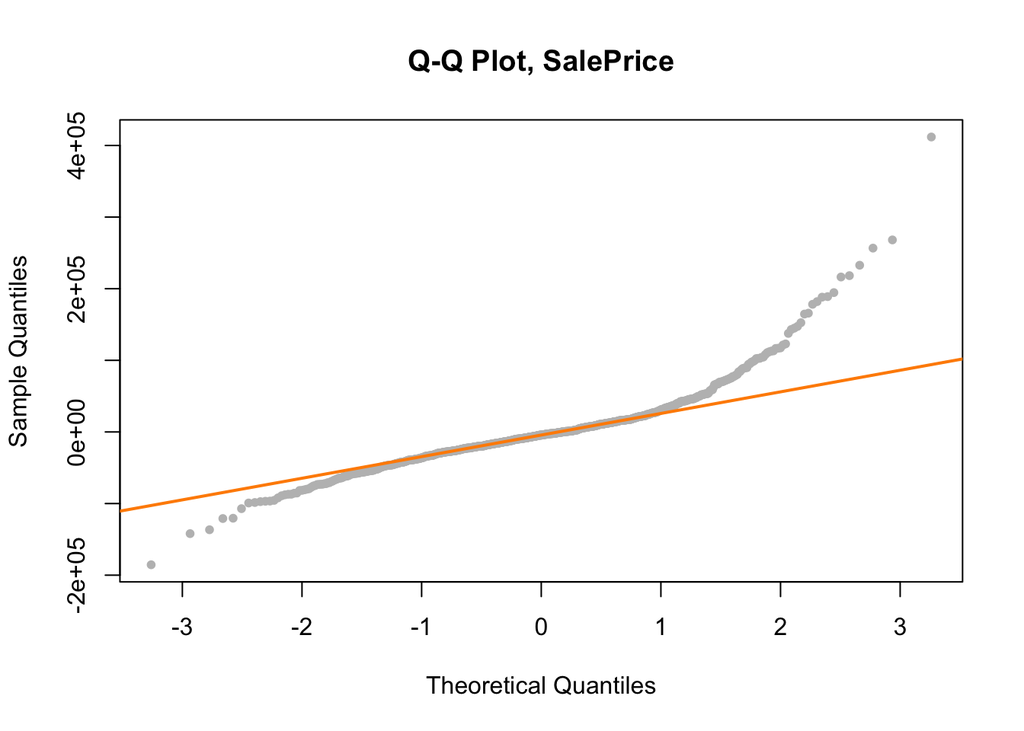

```r
add_model_normality=bptest(model_add)
# Check normality by qqplot, visualize data for better understanding
qqnorm(resid(model_add),main='Q-Q Plot, SalePrice',col='grey',pch=20)
qqline(resid(model_add),col='darkorange',lwd=2)
```

```r
add_model_eq=shapiro.test(resid(model_add))

add_bptest=bptest(model_add)$p.value[[1]]
add_shapiro=shapiro.test(resid(model_add))$p.value[[1]]
```

- In order to pass assumptions test, remove outliers and influential points to fit the model and see an improvement on both tests.

**Remove Outliers and Influential Points**

```r
# Remove influential Points and outliers
train_nout = train[-outliers,]
model_add=lm(SalePrice~.,train_nout)
train_cook = cooks.distance(model_add)
influential=train_cook[train_cook > 4 / length(train_cook)]
non_inf_ind=train_cook <= 4 /length(train_cook)
train_non_inf=train[non_inf_ind,]
############ Model 2 ####################
model_add_sub = lm(SalePrice~.,data=train_non_inf)

#Check Assumptions
add_sub_bptest=bptest(model_add_sub)$p.value[[1]]
add_sub_shapiro=shapiro.test(resid(model_add_sub))$p.value[[1]]
```

**Tranformation on Model**

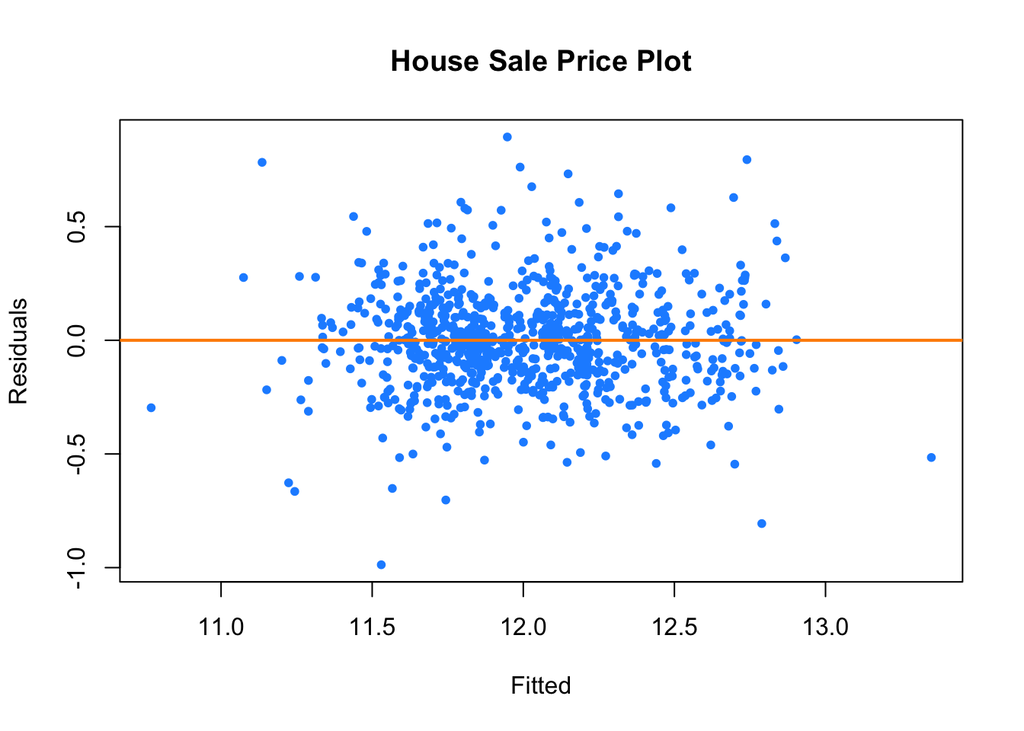

```r
#Transformation on response and remove outliers
model_add_log=lm(log(SalePrice)~.,data=train_nout)
train_cook = cooks.distance(model_add)
influential=train_cook[train_cook > 4 / length(train_cook)]
############## Model 3 ######################
model_add_log_sub = lm(log(SalePrice)~.,data=train_non_inf)
# Assumption tests plot
plot(fitted(model_add_log_sub),resid(model_add_log_sub),col='dodgerblue',pch=20,xlab='Fitted',ylab='Residuals',main='House Sale Price Plot')
abline(h=0,col='darkorange',lwd=2)
```

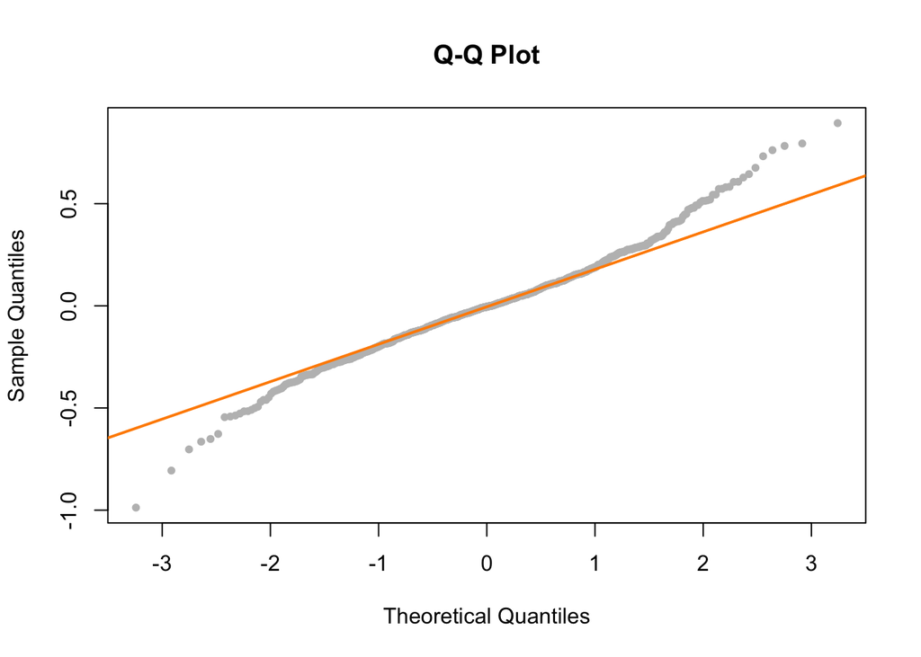

```r
qqnorm(resid(model_add_log_sub),main='Q-Q Plot',col='grey',pch=20)
qqline(resid(model_add_log_sub),col='darkorange',lwd=2)
```

```r
add_log_bptest=bptest(model_add_log_sub)$p.value[[1]]
add_log_shapiro=shapiro.test(resid(model_add_log_sub))$p.value[[1]]
```

- Check how well these additive models perform on training set, by calculating adjusted R squared

**Calcualte Adjusted R squared**

```r
# Check Adjusted R squared on training dataset

adjr_add=summary(model_add)$adj.r.squared
adjr_add_sub=summary(model_add_sub)$adj.r.squared
adjr_add_log=summary(model_add_log_sub)$adj.r.squared
```

- Check how well these additive models perform on test set, by calculating RMSE and R squared. **Calculate RMSE and R squared on Test data**

```r
# Test on test set and get RMSE
RMSE=function(model,validation){
p= predict(model, validation)
error=(p-validation$SalePrice)
RMSE_Model=sqrt(mean(error^2))
RMSE_Model}

RMSE_log=function(model,validation){
p= predict(model, validation)
error=(exp(p)-validation$SalePrice)
RMSE_Model=sqrt(mean(error^2))
RMSE_Model}

# RMSE on test dataset
RMSE_tst_add=RMSE(model_add,test)
RMSE_tst_add_sub=RMSE(model_add_sub,test)
RMSE_tst_add_log=RMSE_log(model_add_log_sub,test)


# R squared on test dataset
rsquared=function(model,validation)
{
p = predict(model, validation)
rss = sum((p - validation$SalePrice) ^ 2)
tss = sum((validation$SalePrice - mean(validation$SalePrice)) ^ 2)
rsq = 1 - rss/tss
rsq
}
rsquared_log=function(model,validation)
{
p = predict(model, validation)
rss = sum((exp(p) - validation$SalePrice) ^ 2)
tss = sum((validation$SalePrice - mean(validation$SalePrice)) ^ 2)
rsq = 1 - rss/tss
rsq
}

rsquared_test_add=rsquared(model_add,test)
rsquared_test_add_sub=rsquared(model_add_sub,test)
rsquared_test_add_log=rsquared_log(model_add_log_sub,test)
```

- Result Table of the statistics for each additive model

```r
library(knitr)
additive=data.frame(
model=c(
  'Additive Model',
  'Additive Model(outlier&influential removed)',
  'Additive Model(log transformation on SalePrice,outlier&influential removed)'
),
pvalue_bptest=c(
add_bptest,
add_sub_bptest,
add_log_bptest
),
pvalue_shapiro=c(
add_shapiro,
add_sub_shapiro,
add_log_shapiro
),
train_adj_r_squared=c(
adjr_add,
adjr_add_sub,
adjr_add_log
),
test_r_squared=c(
rsquared_test_add,
rsquared_test_add_sub,
rsquared_test_add_log
),
test_RMSE=c(
RMSE_tst_add,
RMSE_tst_add_sub,
RMSE_tst_add_log
)
)

#kable(additive,caption='Additive Models',digits = c(6,6,10,3,3,2))
```

#### Interactive Models (two way interaction)

The selection of interactive models follows the same procedure as the additive model selection

```r
# Start with two way interaction among all factors
########## MODEL 1 ##################
model_int=lm(SalePrice~.^2 ,data=train)
#model_int_non=lm(SalePrice~.^2 ,data=train_non_inf)
#summary(model_int)
#summary(model_int_non)

#Backward BIC to pick a model, I check the this model using all data vs model using all data excluding outliers and influential points, the statistics P are the same. I also check these on assumption tests and it turned out they have a slightly better score(bigger) for all data one.So I decided to use all data to build models.

# int_bic=step(model_int_non,k=log(nrow(train)),trace=0)
# I saved the model chosen from above BIC backward selection for saving rmarkdown knitting time
########## MODEL 2 ##################
int_bic=lm(SalePrice ~ LotArea + Neighborhood + LotArea:Neighborhood,
    data = train)
########## MODEL 3 ##################
# Log transformation on SalePrice
int_bic_log=lm(log(SalePrice) ~ LotArea + Neighborhood + LotArea:Neighborhood,
    data = train)


# Assumption tests: Normality & Equal Variance
plot_resid=function(model){
plot(fitted(model),resid(model),col='dodgerblue',pch=20,xlab='Fitted',ylab='Residuals',main='House Sale Price Plot')
abline(h=0,col='darkorange',lwd=2)}
# draw qqplot
plot_qq=function(model){
qqnorm(resid(model_add),main='Q-Q Plot, SalePrice',col='grey',pch=20)
qqline(resid(model_add),col='darkorange',lwd=2)}
# bptest, shapiro test funcitons
bp=function(model){bptest(model)$p.value[[1]]}
shapiro=function(model){shapiro.test(resid(model))$p.value[[1]]}

#plot_resid(int_bic_log)
#plot_qq(int_bic_log)

# Adjusted R squared traing data
adjr_int=summary(model_int)$adj.r.squared
adjr_int_bic=summary(int_bic)$adj.r.squared
adjr_int_log=summary(int_bic_log)$adj.r.squared

# RMSE
RMSE_tst_int=RMSE(model_int,test)
RMSE_tst_int_bic=RMSE(int_bic,test)
RMSE_tst_int_log=RMSE_log(int_bic_log,test)

# Result Table
interactive=data.frame(
model=c(
  'Interactive Model',
  'Interactive Model, BIC backward chosen',
  'Interactive Model,BIC backward,Log Tranformation on SalePrice'
),
pvalue_bptest=c(
bp(model_int),
bp(int_bic),
bp(int_bic_log)
),
pvalue_shapiro=c(
shapiro(model_int),
shapiro(int_bic),
shapiro(int_bic_log)
),
train_adj_r_squared=c(
adjr_int,
adjr_int_bic,
adjr_int_log
),
test_RMSE=c(
RMSE_tst_int,
RMSE_tst_int_bic,
RMSE_tst_int_log
)
)
#kable(interactive,caption='Interactive Models',digits = c(6,6,25,3,3,2))
```

## Results

```r
kable(additive,caption='Additive Models',digits = c(6,6,10,3,3,2))
```

Additive Models

| model | pvalue_bptest | pvalue_shapiro | train_adj_r_squared | test_r_squared | test_RMSE |
| --- | --- | --- | --- | --- | --- |
| Additive Model | 0.000001 | 0.0e+00 | 0.657 | 0.691 | 45727.87 |
| Additive Model(outlier&influential removed) | 0.000004 | 0.0e+00 | 0.652 | 0.677 | 46794.84 |
| Additive Model(log transformation on SalePrice,outlier&influential removed) | 0.000404 | 8.8e-09 | 0.700 | 0.677 | 46765.27 |

```r
kable(interactive,caption='Interactive Models',digits = c(6,6,25,3,3,2))
```

Interactive Models

| model | pvalue_bptest | pvalue_shapiro | train_adj_r_squared | test_RMSE |
| --- | --- | --- | --- | --- |
| Interactive Model | 1.000000 | 0.000000e+00 | 0.750 | 250178.76 |
| Interactive Model, BIC backward chosen | 0.000000 | 1.780000e-23 | 0.700 | 71230.58 |
| Interactive Model,BIC backward,Log Tranformation on SalePrice | 0.025204 | 5.282712e-12 | 0.677 | 344618.89 |

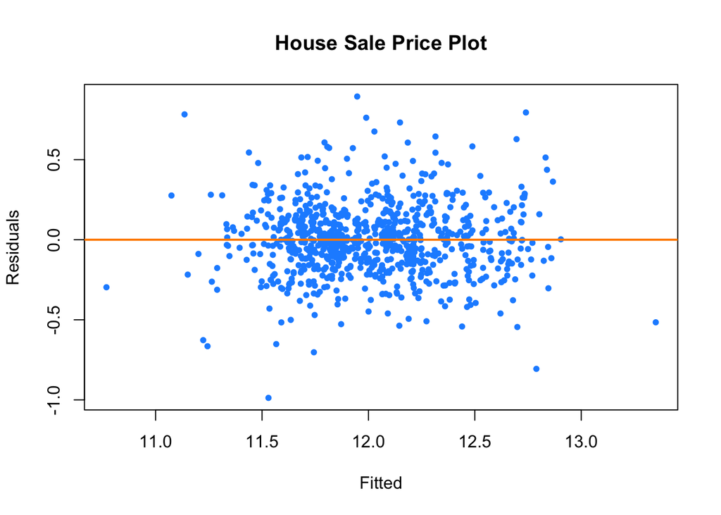

```r
#Assumption plots
plot_resid(model_add_log_sub)
```

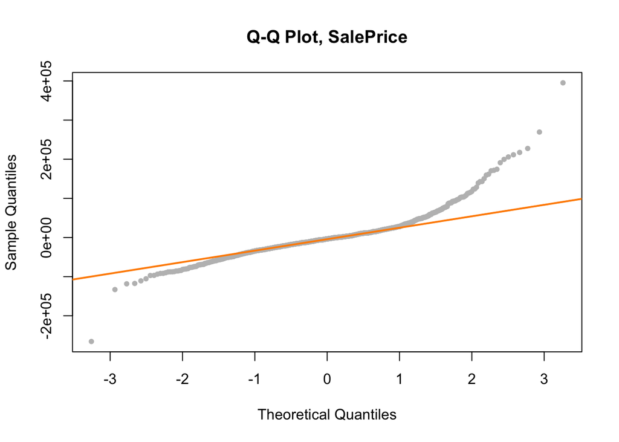

```r
plot_qq(model_add_log_sub)
```

These models all have adjusted r squared between 0.65 to 0.75 (fine score), which show how much is the proportion of response (SalePrice) can be predicted by the independent variables (LotArea, LotFrontage…). Since they are very close, I will not use this as a significant factor to choose model.

The test RMSE show how well our model generalize to data other than the training data. The interactive models all have much higher RMSE (range from 71230 to 344618) than RMSE(all around 45000) of additive model. I take this as an important factor when considering which model to choose.

## Discussion

```r
summary(model_add_log_sub)
```

```
##
## Call:
## lm(formula = log(SalePrice) ~ ., data = train_non_inf)
##
## Residuals:
##      Min       1Q   Median       3Q      Max
## -0.98741 -0.12802 -0.00405  0.11928  0.89414
##
## Coefficients:
##                        Estimate Std. Error t value Pr(>|t|)
## (Intercept)           1.142e+01  1.802e-01  63.380  < 2e-16 ***
## MSZoningFV            1.848e-01  1.231e-01   1.501 0.133669
## MSZoningRH            8.224e-02  1.317e-01   0.625 0.532362
## MSZoningRL            3.051e-01  1.032e-01   2.956 0.003214 **
## MSZoningRM            3.172e-01  9.519e-02   3.332 0.000902 ***
## LotFrontage           2.757e-03  4.873e-04   5.657 2.15e-08 ***
## LotArea               4.001e-06  1.051e-06   3.806 0.000152 ***
## NeighborhoodBlueste  -1.301e-01  2.500e-01  -0.520 0.603078
## NeighborhoodBrDale   -4.918e-01  1.178e-01  -4.173 3.33e-05 ***
## NeighborhoodBrkSide  -5.788e-01  9.504e-02  -6.091 1.76e-09 ***
## NeighborhoodClearCr  -1.953e-01  1.090e-01  -1.793 0.073428 .
## NeighborhoodCollgCr  -1.406e-01  8.147e-02  -1.726 0.084798 .
## NeighborhoodCrawfor  -1.122e-01  9.224e-02  -1.216 0.224374
## NeighborhoodEdwards  -5.327e-01  8.428e-02  -6.321 4.34e-10 ***
## NeighborhoodGilbert  -2.360e-01  8.752e-02  -2.697 0.007149 **
## NeighborhoodIDOTRR   -6.711e-01  1.090e-01  -6.155 1.19e-09 ***
## NeighborhoodMeadowV  -5.362e-01  1.163e-01  -4.612 4.65e-06 ***
## NeighborhoodMitchel  -3.595e-01  9.141e-02  -3.932 9.15e-05 ***
## NeighborhoodNAmes    -4.096e-01  8.166e-02  -5.016 6.52e-07 ***
## NeighborhoodNoRidge   2.362e-01  9.168e-02   2.576 0.010168 *
## NeighborhoodNPkVill  -1.851e-01  1.213e-01  -1.526 0.127288
## NeighborhoodNridgHt   2.851e-01  7.989e-02   3.569 0.000380 ***
## NeighborhoodNWAmes   -1.813e-01  8.967e-02  -2.022 0.043502 *
## NeighborhoodOldTown  -6.291e-01  9.581e-02  -6.566 9.37e-11 ***
## NeighborhoodSawyer   -4.628e-01  8.813e-02  -5.251 1.95e-07 ***
## NeighborhoodSawyerW  -1.579e-01  8.589e-02  -1.839 0.066316 .
## NeighborhoodSomerst   1.097e-01  9.581e-02   1.145 0.252441
## NeighborhoodStoneBr   3.650e-01  9.883e-02   3.693 0.000237 ***
## NeighborhoodSWISU    -4.156e-01  9.987e-02  -4.161 3.51e-05 ***
## NeighborhoodTimber    6.769e-02  9.174e-02   0.738 0.460816
```

[output cut: 15 more lines]

```
## OverallCond6          2.584e-01  1.193e-01   2.166 0.030574 *
## OverallCond7          2.916e-01  1.193e-01   2.445 0.014688 *
## OverallCond8          3.223e-01  1.227e-01   2.628 0.008763 **
## OverallCond9          5.885e-01  1.432e-01   4.109 4.38e-05 ***
## SaleConditionAdjLand  3.991e-02  1.237e-01   0.323 0.747021
## SaleConditionAlloca  -3.849e-03  1.025e-01  -0.038 0.970054
## SaleConditionFamily   1.689e-01  7.615e-02   2.218 0.026821 *
## SaleConditionNormal   9.374e-02  3.094e-02   3.030 0.002525 **
## SaleConditionPartial  1.694e-01  4.244e-02   3.991 7.20e-05 ***
## ---
## Signif. codes:  0 '***' 0.001 '**' 0.01 '*' 0.05 '.' 0.1 ' ' 1
##
## Residual standard error: 0.2274 on 790 degrees of freedom
## Multiple R-squared:  0.719,  Adjusted R-squared:  0.7002
## F-statistic: 38.14 on 53 and 790 DF,  p-value: < 2.2e-16
```

```r
max(data$SalePrice)
```

```
## [1] 755000
```

```r
min(data$SalePrice)
```

```
## [1] 34900
```

Our best model is the additive model with log tranformation on SalePrice and outlier,influential points removed. We could use our model make prediction for house SalePrice based on this model. It is an additive multiple regression model with log tranformation. A fairly simple model to interpret and have a fine test RMSE(46765.27), we could expect our prediction of the average SalePrice for given features (LotArea,Neighborhood…) could be off around $46765, even though this is a small RMSE comparing my other models. The given data have a range of 34900 dollars to 755000 dollars, a RMSE of 46765 could be too much for the saleprice in lower range but should be fine for the upper range.